# Theory Assignment

## Residuals, Sums of Square, and R-Squared

### Residuals

**Residuals** are the difference between the observed value of $Y_i$ and the fitted value $\hat{Y_i}$. Each data point has one residual. Single residuals show how far the observed value is from the regression line.

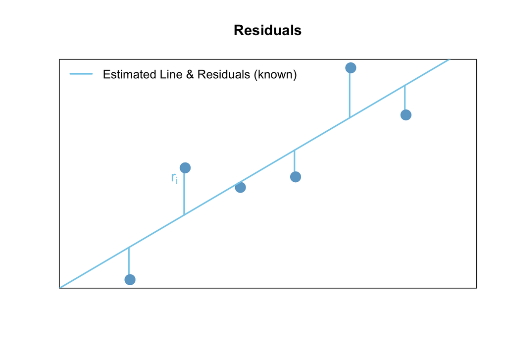

### SSE, SSR, SSTO

Created simple linear regression with X(weight of laptop) and Y(Price_euro) from laptop data set.

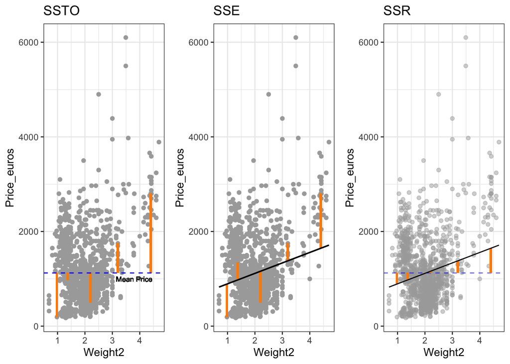

```r
laptops <- read_csv("~/Desktop/Statistics-Notebook/Data/laptops.csv")
laptops <- laptops %>% mutate(Weight2 = parse_number(Weight))
laptops <- laptops %>% mutate(Ram2 = parse_number(Ram))
laptop.lm <-lm(Price_euros ~ Weight2, data=laptops)
laptop2.lm <- lm(Price_euros ~ Inches, data=laptops)
laptop3.lm <- lm(Price_euros~ Ram2, data=laptops)
mean_price <- mean(laptops$Price_euros)
#SSR
SSR <- laptops %>%
  ggplot(aes(x = Weight2, y = Price_euros)) +
  geom_point(color = "darkgrey", alpha = 0.5) +
  geom_hline(yintercept = mean_price, linetype = "dashed", alpha = 0.6, color="blue") +
  geom_segment(aes(x = 1.370, xend = 1.370, y = mean_price, yend = 975.9189
), color = "darkorange", size = 1) +
  geom_segment(aes(x = 2.200, xend = 2.200, y = mean_price, yend = 1159.324
), color = "darkorange", size = 1) +
  geom_segment(aes(x = 0.980
, xend = 0.980
, y = mean_price, yend = 889.7406), color = "darkorange", size = 1) +
  geom_segment(aes(x =4.400, xend = 4.400, y = mean_price, yend = 1645.458), color = "darkorange", size = 1) +
  geom_segment(aes(x = 3.20, xend = 3.20, y = mean_price, yend = 1380.294
), color = "darkorange", size = 1) +
  geom_lm(color = "black", size=0.5) +
  theme_bw() +
  labs(title = "SSR")

#SSTO
SSTO <- laptops %>%
  ggplot(aes(x = Weight2, y = Price_euros)) + geom_point(color="darkgrey", alpa=0.5)+
  geom_segment(aes(x = 1.370, xend = 1.370, y = mean_price, yend = 975.9189
), color = "darkorange", size = 1) +
   geom_segment(aes(x = 2.200, xend = 2.200, y = mean_price, yend = 498.90
), color = "darkorange", size = 1) +
   geom_segment(aes(x = 0.980, xend = 0.980, y = mean_price, yend = 191.90), color = "darkorange", size = 1) +
  geom_segment(aes(x =4.400, xend = 4.400, y = mean_price, yend = 2799.00), color="darkorange", size = 1) +
geom_segment(aes(x = 3.20, xend = 3.20, y = mean_price, yend = 1749.00 ), color = "darkorange", size = 1) +
  geom_hline(yintercept = mean_price, linetype = "dashed", color="blue") +
  geom_text(label = "Mean Price", x = 3.8, y = 1000, size=2.5) +
  theme_bw() +
  labs(title = "SSTO")





#SSE
SSE <- laptops %>%
ggplot(aes(x = Weight2, y = Price_euros)) +
geom_point(color = "darkgrey", alpa=0.5)+
geom_segment(aes(x = 1.370, xend = 1.370,  y=975.9189,yend =1339.69
), color = "darkorange", size = 1) +
geom_segment(aes(x = 2.200, xend = 2.200, y=498.90, yend= 1159.324
), color = "darkorange", size = 1) +
geom_segment(aes(x = 0.980, xend = 0.980,  y = 191.90,yend = 889.7406), color = "darkorange", size = 1) +
geom_segment(aes(x =4.400, xend = 4.400, y = 2799.00,yend=1645.458), color = "darkorange", size = 1) +
geom_segment(aes(x = 3.20, xend = 3.20, y = 1749.00, yend=1380.294), color = "darkorange", size = 1) +
geom_lm(color = "black") +
theme_bw() +
labs(title = "SSE")

ggarrange(SSTO, SSE, SSR, ncol = 3)
```

```r
SSTO1 <- sum((laptops$Price_euros -mean(laptops$Price_euros))^2)
SSR1 <- sum((laptop.lm$fit - mean(laptops$Price_euros))^2)
SSE1 <- sum(laptop.lm$residuals^2)
```

| **SSTO** | **SSE** | **SSR** |
| --- | --- | --- |
| $\text{SSTO} = \sum_{i=1}^n \left(Y_i - \bar{Y}\right)^2$ = 636174961 | $\text{SSE} = \sum_{i=1}^n \left(Y_i - \hat{Y}_i\right)^2$ =608020751 | $\text{SSR} = \sum_{i=1}^n \left(\hat{Y}_i - \bar{Y}\right)^2$=28154211 |
| Measures how much the y-values deviate from the average y-value. | Measures how much the residuals deviate from the regression line. | Measures how much the regression line deviates from the average y-value. |
| `sum( (Y - mean(Y))^2 )` | `sum( (Y - mylm$fit)^2 )` | `sum( (mylm$fit - mean(Y))^2 )` |

SSTO = SSE +SSR

*for example* Laptop with weight 3.2kg and price of 1749 euro is 625.311 far away from the mean of price average. Also, it’s predict value is 1380.294, is 368.706 expensive than predict value. Predict value is 256.605 far away from the average.

### What’s R Squared?

It is a *Proportion of variation in Y explained by the regression*.
$$\\R^2 = \frac{SSR}{SSTO} = 1 - \frac{SSE}{SSTO}\$$
When SSE is small, we can say that regression line explaines data pretty well and it will cause high number of R squared. SSR shows how much regression line far away from average of Y value. So, when SSR is big it will also cause high number of R squared.

First graph uses weight, Second graph uses inches, anad Third graph uses ram as X variable with Y(Price in euros) variable.

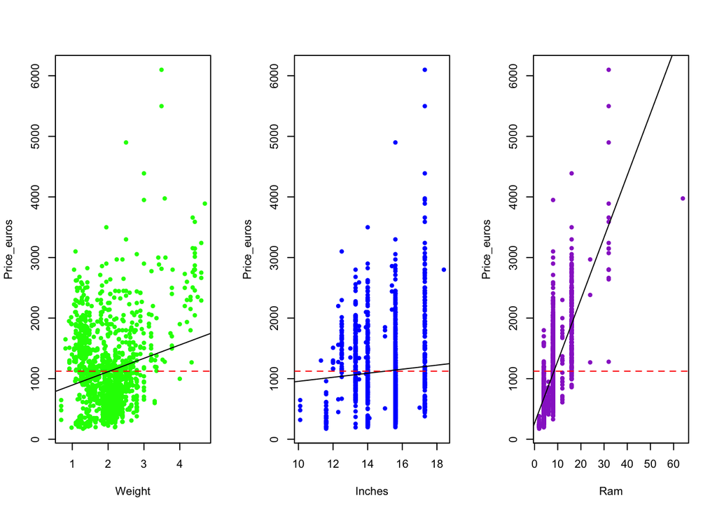

```r
par(mfrow=c(1,3))
#laptop.lm
plot(Price_euros ~ Weight2, data=laptops,pch=20, col="green", xlab="Weight", ylab="Price_euros")
abline(laptop.lm)
abline(h=1123.687, col="red", lty=2)
#laptop2.lm
plot(Price_euros ~ Inches, data=laptops, pch=20, col="blue", xlab="Inches", ylab="Price_euros")
abline(laptop2.lm)
abline(h=1123.687, col="red", lty=2)
#laptop3.lm
plot(Price_euros ~ Ram2, data=laptops, pch=20, col="darkorchid", xlab="Ram", ylab="Price_euros")
abline(laptop3.lm)
abline(h=1123.687, col="red", lty=2)
```

```r
SSTO3 <- sum((laptops$Price_euros -mean(laptops$Price_euros))^2)
SSR3 <- sum((laptop3.lm$fit - mean(laptops$Price_euros))^2)
SSE3 <- sum(laptop3.lm$residuals^2)
SSTO2 <- sum((laptops$Price_euros -mean(laptops$Price_euros))^2)
SSR2 <- sum((laptop2.lm$fit - mean(laptops$Price_euros))^2)
SSE2 <- sum(laptop2.lm$residuals^2)
```

[output not shown]

```r
#summary(laptop.lm)
#summary(laptop2.lm)
#summary(laptop3.lm)
```

f R-squared is close to 1, it means it has an excellent fit. In our example, last graph is more than 0.5. P-value of three models are all significant. Residuals standard error indicates how far the data points are from the regression line on average. R-squared values indicate how far the data points are to the fitted values. But don’t trust R squared too much when you interpret the data.